# Answer key for HW1 CDA

TA-Liu Lirong

### 2. Analysis the GDS5037 data (20 points)

(1). (3 points)

```r
library(stringr)      # 使用提取函数
library(dplyr)        # 用导管运算
library(ggplot2)

data=read.csv('C:\\Users\\liulirong\\Desktop\\CDA本科助教\\GDS5037\\GDS5037.csv',encoding='UTF-8',header=TRUE)
```

(2). (5 points)

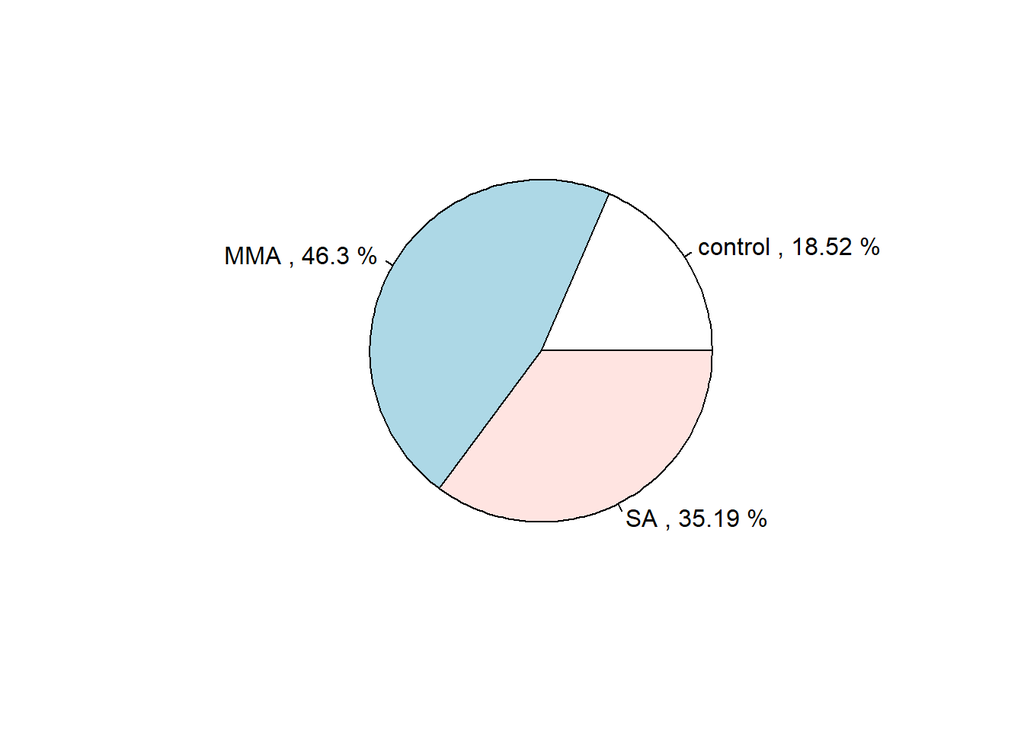

```r
## 提取字符串
patients=data[51:158,1] %>% as.character()
keys="MMA|control|SA"
patients_status=patients %>% str_extract(keys)

## 统计频数和百分比
freq=table(patients_status)               # 频数
perc=prop.table(table(patients_status))   # 百分比

## 绘制饼图
pie(freq,labels=paste(names(freq),",",round(freq / sum(freq) * 100, 2),"%"))
```

(3). (6 points)

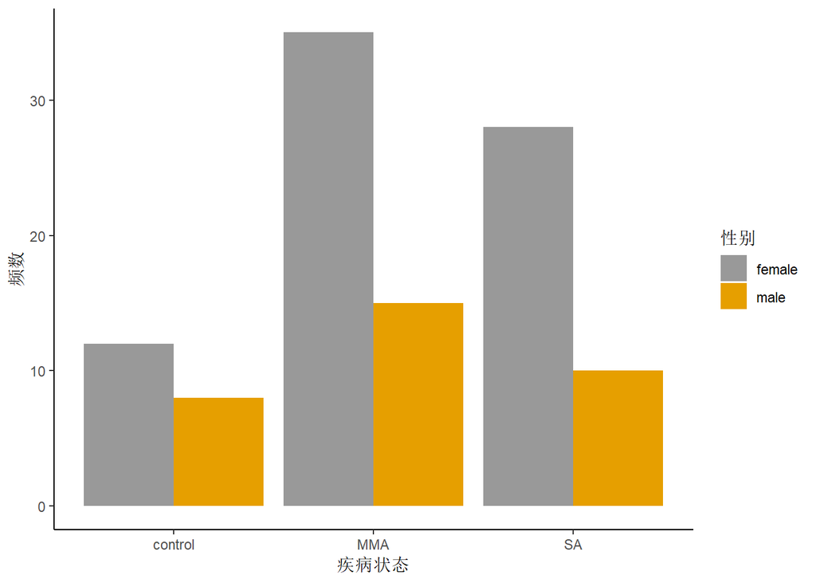

```r
## 男性id
male_info=data[46,1] %>% as.character()          # 信息所在位置
male_id=unlist(strsplit(male_info,","))[-1]

## 女性id
female_info=data[41,1] %>% as.character()        # 信息所在位置
female_id=unlist(strsplit(female_info,","))[-1]

## 将性别、疾病状态与病人ID对应，生成数据集Patients
patients_id=t(data[160,-c(1,2)]) %>% as.character()
Patients=data.frame(ID=patients_id,Status=patients_status)
Patients$Gender=ifelse(patients_id %in% male_id,'male','female')

## 绘制条形图
groups1=Patients %>% group_by(Status,Gender) %>% summarise(freq=n())

ggplot(groups1,aes(x=Status,y=freq,fill=Gender))+
  geom_bar(position="dodge",stat="identity")+                                 #绘制柱状图
  scale_fill_manual(values=c('#999999','#E69F00'))+                           #设置颜色
  xlab("疾病状态") + ylab("频数") + labs(fill="性别")+                        #设置标题
  theme_classic()                                                             #背景设置
```

(4). (3 points)

```r
Patients$FAM174B=t(data[161,-c(1,2)]) %>% as.numeric()
groups2=Patients %>% group_by(Status) %>% summarise(mean=mean(FAM174B),var=var(FAM174B))
groups2
```

```
## # A tibble: 3 x 3
##   Status   mean    var
##   <fct>   <dbl>  <dbl>
## 1 control  11.2 0.0448
## 2 MMA      11.2 0.0979
## 3 SA       11.1 0.227
```

(5). (3 points)

```r
control=Patients[Patients['Status']=='control','FAM174B']
n_control=length(control)

SA=Patients[Patients['Status']=='SA','FAM174B']
n_SA=length(SA)

## 调用t.test()函数
t.test(control,SA,var.equal = FALSE)
```

```
##
##  Welch Two Sample t-test
##
## data:  control and SA
## t = 1.165, df = 54.906, p-value = 0.2491
## alternative hypothesis: true difference in means is not equal to 0
## 95 percent confidence interval:
##  -0.07611471  0.28746734
## sample estimates:
## mean of x mean of y
##  11.16823  11.06255
```

结论：p值为0.2491，不拒绝原假设，认为两个样本均值相等。

- 可以自己计算t统计量，自由度，从而得到p值

```r
mean1=mean(control)
S1=var(control)
mean2=mean(SA)
S2=var(SA)
t=(mean1-mean2)/sqrt(S1/n_control+S2/n_SA)
df=(S1/n_control+S2/n_SA)^2/((S1/n_control)^2/(n_control-1)+(S2/n_SA)^2/(n_SA-1))
t    # 统计量
```

```
## [1] 1.165009
```

```r
df   # 自由度
```

```
## [1] 54.9063
```

```r
p_value=2*(1-pt(t,df))
p_value
```

```
## [1] 0.2490519
```

### 1.2 (12 points)

nominal: a, d, e ; ordinal: b, c, f

### 1.4 (22 points)

1. (7 points)
   When $\pi=0.5$,
   $$P(Y=0) = C_2^0\pi^0(1-\pi)^2 = 0.25$$
   $$P(Y=1) = C_2^1\pi^1(1-\pi)^1 = 0.5$$
   $$P(Y=2) = C_2^2\pi^0(1-\pi)^0 = 0.25$$
   $$mean = E(Y)=n\pi=1$$
   $$var(Y)=n\pi(1-\pi)=0.5$$
   $$sd(Y)=\sqrt{var(Y)}=\sqrt{2}/2$$
2. (6 points)

[output not shown]

3. (6 points)  
   When Y=1,the likelihood function is 2π(1−π), and the function can be sketched as followed:

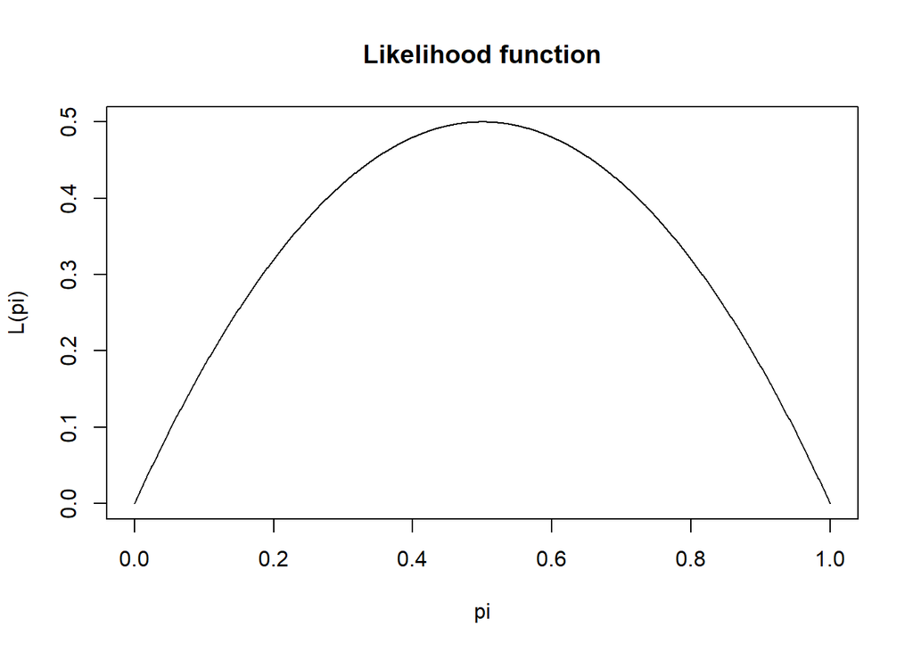

```r
x <- seq(0,1,0.001)
y <- 2*x*(1-x)
plot(x,y,type = "l",xlab = "pi",ylab = "L(pi)",main = "Likelihood function")
```

4. (3 points) Proof:  
   Since the likelihood funciton is $l(\pi)=2\pi(1-\pi)$,  
   the loglikelihood funciton is $logl(\pi)=ln2\pi+ln(1-\pi)$,  
   take derivative, we get $\frac{\partial [logl(\pi)]}{\partial \pi}=\frac{1}{\pi}-\frac{1}{1-\pi}=0$ ,  
   thus,$\hat \pi=0.5$

### 1.5 (5 points)

When y=0 in two flips,the likelihood function:
$$l=\pi^0\times(1-\pi)^2=(1-\pi)^2$$
$$\hat\pi=arg\,\max_{\pi}l=0$$
it’s not reasonable.

### 1.6 (18 points)

1. (2 points)Since n1+n2+n3=n, then if we have fot n1 and n2, we could get n3=n−n1−n2.
2. (10 points)  
   When n=3,we could get:

[output not shown]

3. (3 points)
   Suppose (π1,π2,π3)=(0.25,0.50.25),
   the probability of (1,2,0) is
   $$P(1,2,0)=\frac{3!}{1!2!0!}0.25^1\times0.5^2\times0.25^0=0.1875$$
4. (3 points)  
   n1 follows binomial distribution of n=3, π=0.25, which is n1~B(3,0.25).

### 1.8 (12 points)

1. (2 points)  
   $\hat\pi=\frac{y}{n}=0.294$
2. (6 points)
   $$H_0:\pi\ge0.5\\H_A:\pi<0.5$$
   $$z=\frac{p-\pi_0}{\sqrt{\frac{\pi_0(1-\pi_0)}{n}}}=\frac{0.294-0.5}{\sqrt{\frac{0.5\times(1-0.5)}{1170}}}=-14.09$$
   $$P_{value}=P(z<-14.09)=\Phi(-14.09)=0$$
   Thus,we should reject $H_0$,a minority of the population would say ‘Yes’.
- 如果使用$H_0:\pi=0.5;H_A:\pi\ne0.5$，需要结合置信区间，说明置信区间在0.5左侧，才能得出少数人回答“YES”的结论。
3. (4 points)

99% confidence interval:
$$0.294\pm 2.58\times \sqrt{\frac{0.294\times(1-0.294)}{1170}}=(0.260,0.328)$$

### 1.12 (11 points)

Since π denotes the population proportion who would say “yes”, here we got p=0.

1. (2 points)  
   When we try to conduct the “Wald Test”, we get $z=\frac{0-0.5}{\sqrt{0(1-0)/25}}$,which has no meaning.
2. (3 points)  
   Considering “Wald confidence interval” for π:$p\pm z_{\alpha/2}(SE)$, we get $SE=\sqrt{0(1-0)/25}=0$, then the confidence interval=(0, 0).So it is unbelievable.
3. (4 points)
   The “score test”, $z=\frac{0-0.5}{\sqrt{0.5(1-0.5)/25}}=-5$,and
   $$P_{value}=2*P(z<-5)=0$$
4. (2 points)
   First, we have $z=\frac{0-\pi_0}{\sqrt{\pi_0(1-\pi_0)/25}}$ .Then we should let |z|<1.96. That is
   $$|\frac{0-\pi_0}{\sqrt{\pi_0(1-\pi_0)/25}}|<1.96$$
   $$\frac{5\pi_0}{\sqrt{\pi_0(1-\pi_0)}}<1.96$$
   $$25\pi_0<3.8416-3.8416\pi_0$$
   $$\pi_0<0.133$$
   Thus, the confidence interval is (0,0.133)

If
$$H_0:\pi=0.133\\H_1:\pi\ne0.133$$
$$z=\frac{0-0.133}{\sqrt{0.133\times(1-0.133)/25}}=-1.96$$
$$P_{value}=2P(z<-1.96)=0.05$$